# Reanalysis of Staub’s (2024) Experiment 1

2025-02-14

This is a reanalysis of the data in Staub’s (2024) Experiment 1.

Staub, A. (2024). The function/content word distinction and eye movements in reading. Journal of Experimental Psychology: Learning, Memory, and Cognition, 50(6), 967–984. https://doi.org/10.1037/xlm0001301

Staub’s data and original analysis scripts can be accessed here: https://osf.io/8f5w7

## Reading data

Read data file:

```r
# df we will be making changes to
E1 = read.csv("E1data.csv", header = T)

# df from the original study
E1_staub = read.csv("E1data.csv", header = T)
```

Code number of characters in target word and get log of target probability:

```r
E1$target_length = nchar(E1$Target_Word)
E1$log_target_prob = log10(E1$Target_Prob)

E1_staub$target_length = nchar(E1_staub$Target_Word)
E1_staub$log_target_prob = log10(E1_staub$Target_Prob)
```

Factorize subject and item:

```r
E1$subj = as.factor(E1$subj)
E1$item = as.factor(E1$item)

E1_staub$subj = as.factor(E1_staub$subj)
E1_staub$item = as.factor(E1_staub$item)
```

## Recategorizing data

This is Staub’s original set of words:

| Lexical (content) words | Grammatical (function) words |
| --- | --- |
| come | about |
| girl | before |
| good | from |
| know | here |
| little | never |
| love | some |
| make | then |
| money | these |
| name | they |
| night | when |
| people | where |
| think | will |
| time | with |
| want | would |

Some of Staub’s ‘function words’ are lexical according to our definition. These are recategorized here:

```r
E1$Class[E1$Target_Word == "about"] <- "Grammatical"
E1$Class[E1$Target_Word == "before"] <- "Lexical"
E1$Class[E1$Target_Word == "here"] <- "Lexical"
E1$Class[E1$Target_Word == "never"] <- "Lexical"
E1$Class[E1$Target_Word == "then"] <- "Lexical"
E1$Class[E1$Target_Word == "these"] <- "Lexical"
E1$Class[E1$Target_Word == "when"] <- "Lexical"
E1$Class[E1$Target_Word == "where"] <- "Lexical"
E1$Class[E1$Target_Word == "will"] <- "Grammatical"
E1$Class[E1$Target_Word == "with"] <- "Grammatical"
E1$Class[E1$Target_Word == "would"] <- "Grammatical"
E1$Class[E1$Target_Word == "they"] <- "Lexical"

#the words 'some' and 'from' have both lexical and grammatical variants
#each stimulus sentence is therefore recategorized separately
E1$Class <- ifelse(
  E1$Target_Word == "some" & substr(E1$Sentence, 1, 3) == "He ",
  "Lexical",
  E1$Class
)
E1$Class <- ifelse(
  E1$Target_Word == "some" & substr(E1$Sentence, 1, 3) == "It'",
  "Grammatical",
  E1$Class
)
E1$Class <- ifelse(
  E1$Target_Word == "some" & substr(E1$Sentence, 1, 3) == "Cou",
  "Grammatical",
  E1$Class
)
E1$Class <- ifelse(
  E1$Target_Word == "some" & substr(E1$Sentence, 1, 3) == "Eve",
  "Lexical",
  E1$Class
)
E1$Class <- ifelse(
  E1$Target_Word == "some" & substr(E1$Sentence, 1, 3) == "In ",
  "Grammatical",
  E1$Class
)
E1$Class <- ifelse(
  E1$Target_Word == "from" & substr(E1$Sentence, 1, 3) == "Thi",
  "Grammatical",
  E1$Class
)
E1$Class <- ifelse(
  E1$Target_Word == "from" & substr(E1$Sentence, 1, 3) == "Tha",
  "Grammatical",
  E1$Class
)
E1$Class <- ifelse(
  E1$Target_Word == "from" & substr(E1$Sentence, 1, 3) == "Joe",
  "Lexical",
  E1$Class
)
E1$Class <- ifelse(
  E1$Target_Word == "from" & substr(E1$Sentence, 1, 3) == "The",
  "Lexical",
  E1$Class
)
E1$Class <- ifelse(
  E1$Target_Word == "from" & substr(E1$Sentence, 1, 3) == "Her",
  "Grammatical",
  E1$Class
)
E1$Class <- ifelse(
  E1$Target_Word == "from" & substr(E1$Sentence, 1, 3) == "Per",
  "Grammatical",
  E1$Class
)
```

If we keep all the words from the original analysis, our data will be extremely imbalanced. Therefore, we choose to do the analysis only on the words which Staub categorized as ‘function words’.

Deleting the rows where Class is not Lexical or Grammatical (this includes all Staub’s ‘content words’ as well as a few sentences where grammatical status of the target word could not be determined):

```r
E1 <- E1[E1$Class %in% c("Grammatical", "Lexical"), ]
```

The categorization of the target words now looks like this:

| Lexical words | Grammatical words | Words with both a lexical and a grammatical variant |
| --- | --- | --- |
| here | about | some |
| never | with | from |
| before | will |  |
| where | would |  |
| when |  |  |
| these |  |  |
| then |  |  |
| they |  |  |

There is still a higher number of lexical words than grammatical words. But it is not as imbalanced as it would have been if we had kept all of Staub’s ‘content words’ in the analysis.

## Descriptive statistics

### Skipping

Staub’s data:

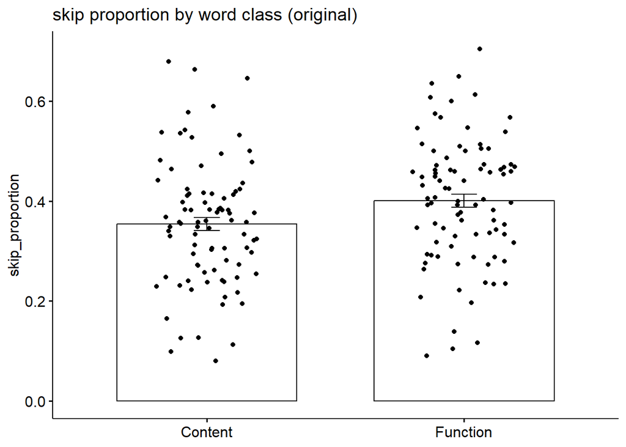

```r
skipping_plot_staub
```

Our recategorization:

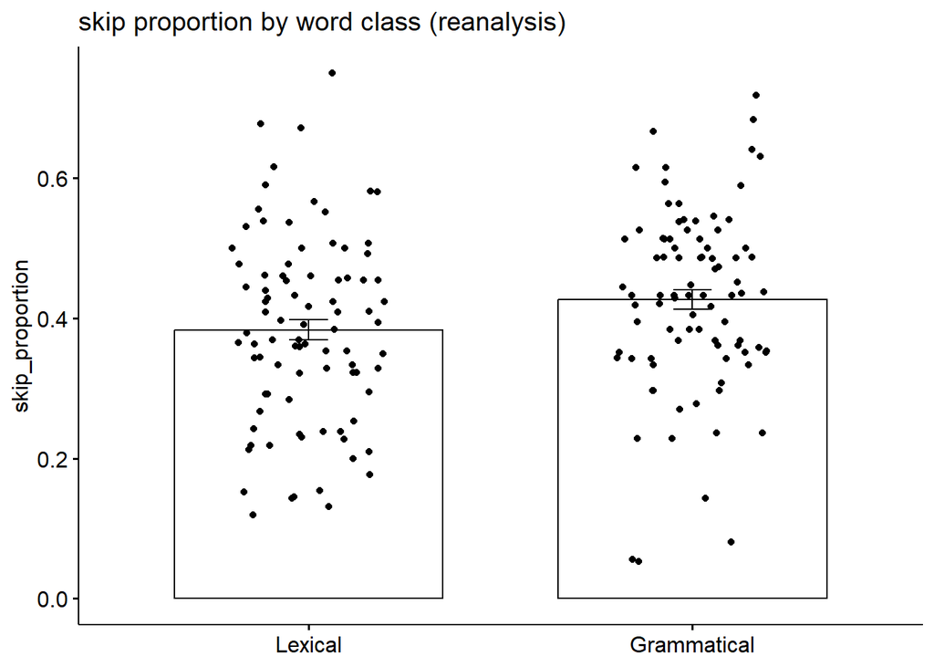

```r
skipping_plot
```

### First fixation duration

```r
# First make a version without the skipped trials
E1_rt_staub = E1_staub[E1_staub$target_skip == 0,]
E1_rt = E1[E1$target_skip == 0,]
```

Staub’s data:

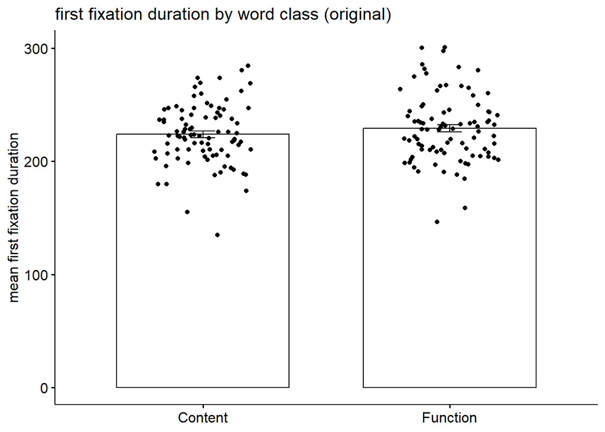

```r
ff_plot_staub
```

Our recategorization:

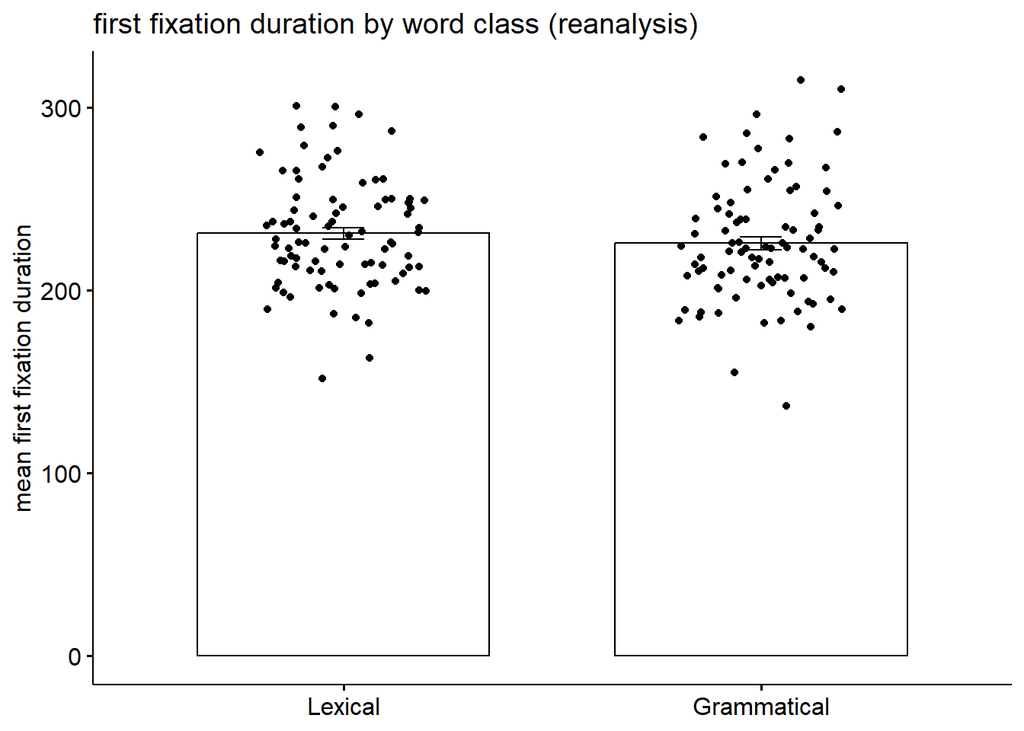

```r
ff_plot
```

### Gaze duration

Staub’s data:

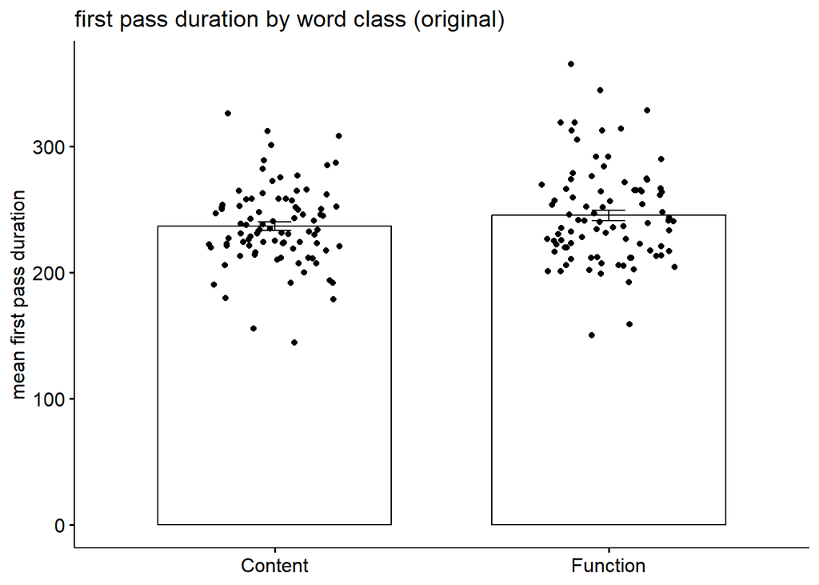

```r
fp_plot_staub
```

Our recategorization:

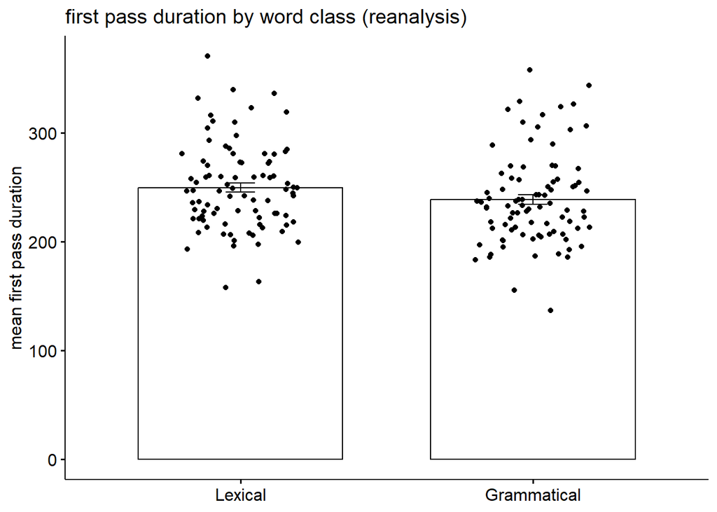

```r
fp_plot
```

## Linear Bayesian mixed-effects models

We ran the same analysis on the recategorized data as was used by Staub (2024). Following the same procedure, we used a two-stage modelling approach: A set of eight predictors was included in an initial model, but predictors were removed from the second, final model if there was no evidence for effects of these variables in the initial model.

```r
# adding frequency to the data frame (because after the recategorization, frequency is no longer balanced between the two groups)
E1$target_zipf_freq[E1$Target_Word == "about"] <- 6.56
E1$target_zipf_freq[E1$Target_Word == "before"] <- 5.9
E1$target_zipf_freq[E1$Target_Word == "from"] <- 6.31
E1$target_zipf_freq[E1$Target_Word == "here"] <- 6.66
E1$target_zipf_freq[E1$Target_Word == "never"] <- 6.13
E1$target_zipf_freq[E1$Target_Word == "some"] <- 6.24
E1$target_zipf_freq[E1$Target_Word == "then"] <- 6.17
E1$target_zipf_freq[E1$Target_Word == "these"] <- 5.96
E1$target_zipf_freq[E1$Target_Word == "they"] <- 6.61
E1$target_zipf_freq[E1$Target_Word == "when"] <- 6.31
E1$target_zipf_freq[E1$Target_Word == "where"] <- 6.26
E1$target_zipf_freq[E1$Target_Word == "will"] <- 6.33
E1$target_zipf_freq[E1$Target_Word == "with"] <- 6.7
E1$target_zipf_freq[E1$Target_Word == "would"] <- 6.25
```

```r
#sum code the binary variables

E1$Preceding_Skip_x = ifelse(E1$preceding_skip == 0, -.5, .5)
E1$Class.x = ifelse(E1$Class == "Lexical", -.5, .5)

E1_staub$Preceding_Skip_x = ifelse(E1_staub$preceding_skip == 0, -.5, .5)
E1_staub$Class.x = ifelse(E1_staub$Class == "Content", -.5, .5)

#center the other predictors

E1$Function_Word_Prob.c = E1$Function_Word_Prob - mean(E1$Function_Word_Prob)
E1$Entropy.c = E1$Entropy - mean(E1$Entropy)
E1$Position.c = E1$Num_Words_Before - mean(E1$Num_Words_Before)
E1$Preceding_Length.c = E1$Preceding_Word_Length - mean(E1$Preceding_Word_Length)
E1$Target_Length.c = E1$target_length - mean(E1$target_length)
E1$Log_Target_Prob.c = E1$log_target_prob - mean(E1$log_target_prob)
# I am including frequency here
E1$Target_zipf_freq.c = E1$target_zipf_freq - mean(E1$target_zipf_freq)

E1_staub$Function_Word_Prob.c = E1_staub$Function_Word_Prob - mean(E1_staub$Function_Word_Prob)
E1_staub$Entropy.c = E1_staub$Entropy - mean(E1_staub$Entropy)
E1_staub$Position.c = E1_staub$Num_Words_Before - mean(E1_staub$Num_Words_Before)
E1_staub$Preceding_Length.c = E1_staub$Preceding_Word_Length - mean(E1_staub$Preceding_Word_Length)
E1_staub$Target_Length.c = E1_staub$target_length - mean(E1_staub$target_length)
E1_staub$Log_Target_Prob.c = E1_staub$log_target_prob - mean(E1_staub$log_target_prob)

#make a version without the skipped trials, for analysis of reading time data

E1.noskip = E1[E1$target_skip == 0,]

E1_staub.noskip = E1_staub[E1_staub$target_skip == 0,]
```

### Skipping

```r
#set prior on the effect of word class
skip_prior = set_prior("normal(0,0.3)", class = "b", coef = "Class.x")
```

#### Staub’s analysis

This code was copy/pasted directly from Staub’s code. That’s why the data frame is called E1 (it corresponds to E1_staub here).

Initial model with all predictors:

```r
skip.model10 <- brm(target_skip~ Class.x +
                      Function_Word_Prob.c +
                      Entropy.c +
                      Position.c +
                      Preceding_Length.c +
                      Target_Length.c +
                      Log_Target_Prob.c +
                      Preceding_Skip_x +
                     (1 + Class.x|subj) +
                     (1|item),
                   prior = skip_prior,
                   sample_prior = "yes",
                   cores = 4,
                   family = bernoulli,
                   iter = 4000,
                   data = E1)

summary(skip.model10)
```

Staub does not give the full summary of the initial model (and running it takes a long time, so we haven’t done that). But he reports no hints of effects of function word probability, entropy, or log_target_probability. These are removed from the model.

The second model:

```r
skip.model11 <- brm(target_skip~ Class.x +
                      Position.c +
                      Preceding_Length.c +
                      Target_Length.c +
                      Preceding_Skip_x +
                      (1 + Class.x|subj) +
                      (1|item),
                    prior = skip_prior,
                    sample_prior = "yes",
                    cores = 4,
                    family = bernoulli,
                    iter = 4000,
                    data = E1)

summary(skip.model11)
```

Staub reports this summary of the second model:

```r
Family: bernoulli
Links: mu = logit
Formula: target_skip ~ Class.x + Position.c + Preceding_Length.c + Target_Length.c + Preceding_Skip_x + (1 + Class.x | subj) + (1 | item)
Data: E1 (Number of observations: 18718)
Draws: 4 chains, each with iter = 4000; warmup = 2000; thin = 1;
total post-warmup draws = 8000

Group-Level Effects:
  ~item (Number of levels: 223)
              Estimate Est.Error l-95% CI u-95% CI Rhat Bulk_ESS Tail_ESS
sd(Intercept)     0.40      0.03     0.34     0.46 1.00     3731     6149

~subj (Number of levels: 88)
                       Estimate Est.Error l-95% CI u-95% CI Rhat Bulk_ESS Tail_ESS
sd(Intercept)              0.89      0.07     0.75     1.04 1.00     1609     2993
sd(Class.x)                0.27      0.05     0.16     0.38 1.00     3207     4052
cor(Intercept,Class.x)     0.03      0.18    -0.33     0.39 1.00    10930     6663

Population-Level Effects:
                   Estimate Est.Error l-95% CI u-95% CI Rhat Bulk_ESS Tail_ESS
Intercept             -0.85      0.10    -1.04    -0.66 1.01      842     1495
Class.x                0.08      0.07    -0.07     0.22 1.00     5526     5663
Position.c             0.08      0.01     0.06     0.09 1.00     5668     6700
Preceding_Length.c    -0.12      0.02    -0.15    -0.09 1.00     5360     6154
Target_Length.c       -0.51      0.05    -0.61    -0.42 1.00     5294     5848
Preceding_Skip_x      -2.27      0.05    -2.36    -2.18 1.00    15297     5770

Draws were sampled using sampling(NUTS). For each parameter, Bulk_ESS
and Tail_ESS are effective sample size measures, and Rhat is the potential
scale reduction factor on split chains (at convergence, Rhat = 1).
```

We can see that while the mean of the posterior distribution for the effect of word class is in the direction of more skipping of function words, the credible interval on this estimate extends on both sides of 0. This means that there is no strong evidence for an effect of word class.

#### Our reanalysis

Initial model with all predictors (frequency included):

```r
skip.model10 <- brm(target_skip~ Class.x +
                      Entropy.c +
                      Position.c +
                      Preceding_Length.c +
                      Target_Length.c +
                      Log_Target_Prob.c +
                      Preceding_Skip_x +
                      Target_zipf_freq.c +
                     (1 + Class.x|subj) +
                     (1|item),
                   prior = skip_prior,
                   sample_prior = "yes",
                   cores = 4,
                   family = bernoulli,
                   iter = 4000,
                   data = E1)

summary(skip.model10)
```

This is the summary of the initial model:

```r
> summary(skip.model10)
Family: bernoulli
  Links: mu = logit
Formula: target_skip ~ Class.x + Entropy.c + Position.c + Preceding_Length.c + Target_Length.c + Log_Target_Prob.c + Preceding_Skip_x + Target_zipf_freq.c + (1 + Class.x | subj) + (1 | item)
   Data: E1 (Number of observations: 8887)
  Draws: 4 chains, each with iter = 4000; warmup = 2000; thin = 1;
         total post-warmup draws = 8000

Multilevel Hyperparameters:
~item (Number of levels: 106)
              Estimate Est.Error l-95% CI u-95% CI Rhat Bulk_ESS Tail_ESS
sd(Intercept)     0.41      0.04     0.34     0.51 1.00     3233     4654

~subj (Number of levels: 88)
                       Estimate Est.Error l-95% CI u-95% CI Rhat Bulk_ESS Tail_ESS
sd(Intercept)              0.89      0.08     0.75     1.05 1.00     1334     2413
sd(Class.x)                0.16      0.08     0.01     0.32 1.00     1927     1973
cor(Intercept,Class.x)    -0.54      0.33    -0.98     0.30 1.00     4127     3418

Regression Coefficients:
                   Estimate Est.Error l-95% CI u-95% CI Rhat Bulk_ESS Tail_ESS
Intercept             -0.85      0.11    -1.07    -0.64 1.00      904     1928
Class.x                0.07      0.11    -0.14     0.27 1.00     3034     4832
Entropy.c              0.01      0.04    -0.07     0.10 1.00     2744     4563
Position.c             0.09      0.01     0.06     0.11 1.00     2909     4568
Preceding_Length.c    -0.09      0.02    -0.13    -0.04 1.00     2426     4334
Target_Length.c       -0.74      0.10    -0.94    -0.55 1.00     2506     4156
Log_Target_Prob.c      0.04      0.09    -0.14     0.21 1.00     2351     4199
Preceding_Skip_x      -2.30      0.07    -2.44    -2.16 1.00     8514     5905
Target_zipf_freq.c    -0.37      0.27    -0.90     0.17 1.00     2447     3866

Draws were sampled using sampling(NUTS). For each parameter, Bulk_ESS
and Tail_ESS are effective sample size measures, and Rhat is the potential
scale reduction factor on split chains (at convergence, Rhat = 1).
```

There seem to be no hints of an effect of entropy or log target probability. These predictors are removed from the model.

The second model now looks like this:

```r
skip.model11 <- brm(target_skip~ Class.x +
                      Position.c +
                      Preceding_Length.c +
                      Target_Length.c +
                      Preceding_Skip_x +
                      Target_zipf_freq.c +
                      (1 + Class.x|subj) +
                      (1|item),
                    prior = skip_prior,
                    sample_prior = "yes",
                    cores = 4,
                    family = bernoulli,
                    iter = 4000,
                    data = E1)

summary(skip.model11)
```

Summary of the second model:

```r
> summary(skip.model11)
 Family: bernoulli
  Links: mu = logit
Formula: target_skip ~ Class.x + Position.c + Preceding_Length.c + Target_Length.c + Preceding_Skip_x + Target_zipf_freq.c + (1 + Class.x | subj) + (1 | item)
   Data: E1 (Number of observations: 8887)
  Draws: 4 chains, each with iter = 4000; warmup = 2000; thin = 1;
         total post-warmup draws = 8000

Multilevel Hyperparameters:
~item (Number of levels: 106)
              Estimate Est.Error l-95% CI u-95% CI Rhat Bulk_ESS Tail_ESS
sd(Intercept)     0.41      0.04     0.33     0.49 1.00     3115     5347

~subj (Number of levels: 88)
                       Estimate Est.Error l-95% CI u-95% CI Rhat Bulk_ESS Tail_ESS
sd(Intercept)              0.89      0.08     0.75     1.05 1.00     2244     3303
sd(Class.x)                0.16      0.08     0.01     0.33 1.00     2493     2718
cor(Intercept,Class.x)    -0.54      0.34    -0.98     0.29 1.00     7152     4422

Regression Coefficients:
                   Estimate Est.Error l-95% CI u-95% CI Rhat Bulk_ESS Tail_ESS
Intercept             -0.85      0.11    -1.06    -0.63 1.00     1424     2096
Class.x                0.08      0.10    -0.11     0.27 1.00     5178     5919
Position.c             0.09      0.01     0.06     0.12 1.00     5179     5597
Preceding_Length.c    -0.09      0.02    -0.13    -0.04 1.00     5070     5535
Target_Length.c       -0.75      0.10    -0.94    -0.56 1.00     4421     5177
Preceding_Skip_x      -2.30      0.07    -2.43    -2.16 1.00    13299     6362
Target_zipf_freq.c    -0.38      0.26    -0.90     0.14 1.00     4429     4652

Draws were sampled using sampling(NUTS). For each parameter, Bulk_ESS
and Tail_ESS are effective sample size measures, and Rhat is the potential
scale reduction factor on split chains (at convergence, Rhat = 1).
```

The mean of the posterior distribution for the effect of word class is in the direction of more skipping of grammatical words. But again, the credible interval extends on both sides of 0, so there is no strong evidence for an effect of word class on skipping.

### First fixation duration

#### Staub’s analysis

```r
ff_fp_prior = set_prior("normal(0,0.05)", class = "b", coef = "Class.x")
```

Initial model with all predictors:

```r
ff.model10 <- brm(log(ffR3)~ Class.x +
                      Function_Word_Prob.c +
                      Entropy.c +
                      Position.c +
                      Preceding_Length.c +
                      Target_Length.c +
                      Log_Target_Prob.c +
                      Preceding_Skip_x +
                      (1 + Class.x|subj) +
                      (1|item),
                    prior = ff_fp_prior,
                    sample_prior = "yes",
                    cores = 4,
                    iter = 4000,
                    data = E1.noskip)

summary(ff.model10)
```

Staub does not report the summary of the initial model (and it takes too long to run it), but he writes that four predictors showed no hint of an effect: entropy, number of preceding words, target word length, and preceding word length.

These were removed from the model:

```r
ff.model11 <- brm(log(ffR3)~ Class.x +
                    Function_Word_Prob.c +
                    Log_Target_Prob.c +
                    Preceding_Skip_x +
                    (1 + Class.x|subj) +
                    (1|item),
                  prior = ff_fp_prior,
                  sample_prior = "yes",
                  cores = 4,
                  iter = 4000,
                  data = E1.noskip)

summary(ff.model11)
```

Staub reports the summary of this second model:

```r
Family: gaussian
Links: mu = identity; sigma = identity
Formula: log(ffR3) ~ Class.x + Function_Word_Prob.c + Log_Target_Prob.c + Preceding_Skip_x + (1 + Class.x | subj) + (1 | item)
Data: E1.noskip (Number of observations: 11650)
Draws: 4 chains, each with iter = 4000; warmup = 2000; thin = 1;
total post-warmup draws = 8000

Group-Level Effects:
  ~item (Number of levels: 223)
              Estimate Est.Error l-95% CI u-95% CI Rhat Bulk_ESS Tail_ESS
sd(Intercept)     0.05      0.00     0.04     0.06 1.00     3846     5570

~subj (Number of levels: 88)
                       Estimate Est.Error l-95% CI u-95% CI Rhat Bulk_ESS Tail_ESS
sd(Intercept)              0.12      0.01     0.10     0.14 1.00     1616     3004
sd(Class.x)                0.03      0.01     0.01     0.05 1.00     1354      936
cor(Intercept,Class.x)     0.17      0.21    -0.23     0.60 1.00     4813     1897

Population-Level Effects:
                     Estimate Est.Error l-95% CI u-95% CI Rhat Bulk_ESS Tail_ESS
Intercept                5.37      0.01     5.34     5.39 1.00     1136     2206
Class.x                  0.02      0.01    -0.00     0.04 1.00     6289     6349
Function_Word_Prob.c     0.04      0.02    -0.01     0.08 1.00     6616     6372
Log_Target_Prob.c       -0.02      0.01    -0.03    -0.01 1.00     7330     6513
Preceding_Skip_x         0.06      0.01     0.05     0.07 1.00    13774     6635

Family Specific Parameters:
  Estimate Est.Error l-95% CI u-95% CI Rhat Bulk_ESS Tail_ESS
sigma     0.29      0.00     0.29     0.30 1.00    16155     6250

Draws were sampled using sampling(NUTS). For each parameter, Bulk_ESS
and Tail_ESS are effective sample size measures, and Rhat is the potential
scale reduction factor on split chains (at convergence, Rhat = 1).
```

Staub (2024) writes: “for the critical effect of word class, the effect is in the opposite direction from that predicted by our hypothesis: first fixation durations are longer on function words than content words. But the lower bound of the credible interval for this effect is at 0, and we obtained a BF of 1.19 for the effect of word class, indicating that the data do not provide strong evidence either for or against a null effect.”

#### Our reanalysis

```r
ff_fp_prior = set_prior("normal(0,0.05)", class = "b", coef = "Class.x")
```

Model with all predictors (excluding function_word_prob):

```r
ff.model10 <- brm(log(ffR3)~ Class.x +
                      Entropy.c +
                      Position.c +
                      Preceding_Length.c +
                      Target_Length.c +
                      Log_Target_Prob.c +
                      Preceding_Skip_x +
                      Target_zipf_freq.c +
                      (1 + Class.x|subj) +
                      (1|item),
                    prior = ff_fp_prior,
                    sample_prior = "yes",
                    cores = 4,
                    iter = 4000,
                    data = E1.noskip)

summary(ff.model10)
```

Summary of the initial model:

```r
> summary(ff.model10)
 Family: gaussian
  Links: mu = identity; sigma = identity
Formula: log(ffR3) ~ Class.x + Entropy.c + Position.c + Preceding_Length.c + Target_Length.c + Log_Target_Prob.c + Preceding_Skip_x + Target_zipf_freq.c + (1 + Class.x | subj) + (1 | item)
   Data: E1.noskip (Number of observations: 5333)
  Draws: 4 chains, each with iter = 4000; warmup = 2000; thin = 1;
         total post-warmup draws = 8000

Multilevel Hyperparameters:
~item (Number of levels: 106)
              Estimate Est.Error l-95% CI u-95% CI Rhat Bulk_ESS Tail_ESS
sd(Intercept)     0.04      0.01     0.03     0.05 1.00     3160     4075

~subj (Number of levels: 88)
                       Estimate Est.Error l-95% CI u-95% CI Rhat Bulk_ESS Tail_ESS
sd(Intercept)              0.12      0.01     0.11     0.15 1.00     1715     2985
sd(Class.x)                0.02      0.01     0.00     0.04 1.00     2809     3893
cor(Intercept,Class.x)     0.29      0.46    -0.80     0.96 1.00     6999     4163

Regression Coefficients:
                   Estimate Est.Error l-95% CI u-95% CI Rhat Bulk_ESS Tail_ESS
Intercept              5.38      0.01     5.35     5.40 1.00     1091     1562
Class.x               -0.03      0.01    -0.06    -0.00 1.00     4886     5178
Entropy.c              0.01      0.01    -0.00     0.02 1.00     5062     5729
Position.c            -0.00      0.00    -0.00     0.00 1.00     5380     6078
Preceding_Length.c     0.00      0.00    -0.00     0.01 1.00     5643     6225
Target_Length.c        0.02      0.01     0.00     0.05 1.00     3421     5025
Log_Target_Prob.c     -0.01      0.01    -0.03     0.02 1.00     4708     4811
Preceding_Skip_x       0.04      0.01     0.02     0.06 1.00     8048     6033
Target_zipf_freq.c     0.04      0.03    -0.02     0.11 1.00     3857     4456

Further Distributional Parameters:
      Estimate Est.Error l-95% CI u-95% CI Rhat Bulk_ESS Tail_ESS
sigma     0.30      0.00     0.29     0.31 1.00    10774     5465

Draws were sampled using sampling(NUTS). For each parameter, Bulk_ESS
and Tail_ESS are effective sample size measures, and Rhat is the potential
scale reduction factor on split chains (at convergence, Rhat = 1).
```

There is no hint of an effect of entropy, position, preceding_length or log_target_prob.  
Second model:

```r
ff.model11 <- brm(log(ffR3)~ Class.x +
                    Target_Length.c +
                    Preceding_Skip_x +
                    Target_zipf_freq.c +
                    (1 + Class.x|subj) +
                    (1|item),
                  prior = ff_fp_prior,
                  sample_prior = "yes",
                  cores = 4,
                  iter = 4000,
                  data = E1.noskip)

summary(ff.model11)
```

Summary of the second model:

```r
> summary(ff.model11)
 Family: gaussian
  Links: mu = identity; sigma = identity
Formula: log(ffR3) ~ Class.x + Target_Length.c + Preceding_Skip_x + Target_zipf_freq.c + (1 + Class.x | subj) + (1 | item)
   Data: E1.noskip (Number of observations: 5333)
  Draws: 4 chains, each with iter = 4000; warmup = 2000; thin = 1;
         total post-warmup draws = 8000

Multilevel Hyperparameters:
~item (Number of levels: 106)
              Estimate Est.Error l-95% CI u-95% CI Rhat Bulk_ESS Tail_ESS
sd(Intercept)     0.04      0.01     0.03     0.05 1.00     3107     4393

~subj (Number of levels: 88)
                       Estimate Est.Error l-95% CI u-95% CI Rhat Bulk_ESS Tail_ESS
sd(Intercept)              0.12      0.01     0.11     0.15 1.00     1767     2756
sd(Class.x)                0.01      0.01     0.00     0.04 1.00     2475     3833
cor(Intercept,Class.x)     0.28      0.46    -0.80     0.96 1.00     8293     4677

Regression Coefficients:
                   Estimate Est.Error l-95% CI u-95% CI Rhat Bulk_ESS Tail_ESS
Intercept              5.38      0.01     5.35     5.40 1.00     1244     2738
Class.x               -0.03      0.01    -0.05    -0.00 1.00     5802     5993
Target_Length.c        0.02      0.01    -0.00     0.04 1.00     4683     4932
Preceding_Skip_x       0.03      0.01     0.02     0.05 1.00     9713     6821
Target_zipf_freq.c     0.03      0.03    -0.04     0.10 1.00     4467     4852

Further Distributional Parameters:
      Estimate Est.Error l-95% CI u-95% CI Rhat Bulk_ESS Tail_ESS
sigma     0.30      0.00     0.29     0.31 1.00    10817     4872

Draws were sampled using sampling(NUTS). For each parameter, Bulk_ESS
and Tail_ESS are effective sample size measures, and Rhat is the potential
scale reduction factor on split chains (at convergence, Rhat = 1).
```

Here there is an effect of word class in the expected direction (longer fixations on lexical words) and the credible interval just excludes 0.

### Gaze duration

#### Staub’s analysis

Initial model with all predictors:

```r
fp.model10 <- brm(log(fpR3)~ Class.x +
                    Function_Word_Prob.c +
                    Entropy.c +
                    Position.c +
                    Preceding_Length.c +
                    Target_Length.c +
                    Log_Target_Prob.c +
                    Preceding_Skip_x +
                    (1 + Class.x|subj) +
                    (1|item),
                  prior = ff_fp_prior,
                  sample_prior = "yes",
                  cores = 4,
                  iter = 4000,
                  data = E1.noskip)

summary(fp.model10)
```

Staub does not report the summary of the initial model but writes that the same four predictors were dropped as in the first_fixation analysis: entropy, number of preceding words, target word length, and preceding word length.

The second model then looks like this:

```r
fp.model11 <- brm(log(fpR3)~ Class.x +
                    Function_Word_Prob.c +
                    Log_Target_Prob.c +
                    Preceding_Skip_x +
                    (1 + Class.x|subj) +
                    (1|item),
                  prior = ff_fp_prior,
                  sample_prior = "yes",
                  cores = 4,
                  iter = 4000,
                  data = E1.noskip)

summary(fp.model11)
```

Staub reports this summary of the second model:

```r
Family: gaussian
Links: mu = identity; sigma = identity
Formula: log(fpR3) ~ Class.x + Function_Word_Prob.c + Log_Target_Prob.c + Preceding_Skip_x + (1 + Class.x | subj) + (1 | item)
Data: E1.noskip (Number of observations: 11650)
Draws: 4 chains, each with iter = 4000; warmup = 2000; thin = 1;
total post-warmup draws = 8000

Group-Level Effects:
  ~item (Number of levels: 223)
              Estimate Est.Error l-95% CI u-95% CI Rhat Bulk_ESS Tail_ESS
sd(Intercept)     0.06      0.00     0.05     0.07 1.00     3255     5047

~subj (Number of levels: 88)
                       Estimate Est.Error l-95% CI u-95% CI Rhat Bulk_ESS Tail_ESS
sd(Intercept)              0.13      0.01     0.11     0.16 1.01     1161     2014
sd(Class.x)                0.06      0.01     0.04     0.08 1.00     3353     4233
cor(Intercept,Class.x)     0.30      0.15     0.01     0.58 1.00     4222     4846

Population-Level Effects:
                     Estimate Est.Error l-95% CI u-95% CI Rhat Bulk_ESS Tail_ESS
Intercept                5.41      0.01     5.38     5.44 1.01      640     1409
Class.x                  0.02      0.01    -0.00     0.05 1.00     3053     4777
Function_Word_Prob.c     0.05      0.02    -0.00     0.10 1.00     3646     4586
Log_Target_Prob.c       -0.03      0.01    -0.04    -0.01 1.00     3741     4550
Preceding_Skip_x         0.07      0.01     0.06     0.09 1.00     8509     6314

Family Specific Parameters:
  Estimate Est.Error l-95% CI u-95% CI Rhat Bulk_ESS Tail_ESS
sigma     0.33      0.00     0.33     0.34 1.00    11744     5938

Draws were sampled using sampling(NUTS). For each parameter, Bulk_ESS
and Tail_ESS are effective sample size measures, and Rhat is the potential
scale reduction factor on split chains (at convergence, Rhat = 1).
```

Staub (2024): “Again, the effect of word class is in the opposite direction of our initial prediction, with slightly longer gaze durations for function words. The BF for the effect of word class is 0.92, again indicating that the data do not provide evidence either for or against the null hypothesis.”

#### Our reanalysis

Initial model with all predictors (excluding function word probability):

```r
fp.model10 <- brm(log(fpR3)~ Class.x +
                    Entropy.c +
                    Position.c +
                    Preceding_Length.c +
                    Target_Length.c +
                    Log_Target_Prob.c +
                    Preceding_Skip_x +
                    Target_zipf_freq.c +
                    (1 + Class.x|subj) +
                    (1|item),
                  prior = ff_fp_prior,
                  sample_prior = "yes",
                  cores = 4,
                  iter = 4000,
                  data = E1.noskip)

summary(fp.model10)
```

Summary of the initial model:

```r
summary(fp.model10)
 Family: gaussian
  Links: mu = identity; sigma = identity
Formula: log(fpR3) ~ Class.x + Entropy.c + Position.c + Preceding_Length.c + Target_Length.c + Log_Target_Prob.c + Preceding_Skip_x + Target_zipf_freq.c + (1 + Class.x | subj) + (1 | item)
   Data: E1.noskip (Number of observations: 5333)
  Draws: 4 chains, each with iter = 4000; warmup = 2000; thin = 1;
         total post-warmup draws = 8000

Multilevel Hyperparameters:
~item (Number of levels: 106)
              Estimate Est.Error l-95% CI u-95% CI Rhat Bulk_ESS Tail_ESS
sd(Intercept)     0.05      0.01     0.04     0.07 1.00     3308     5095

~subj (Number of levels: 88)
                       Estimate Est.Error l-95% CI u-95% CI Rhat Bulk_ESS Tail_ESS
sd(Intercept)              0.14      0.01     0.12     0.17 1.00     1552     3430
sd(Class.x)                0.02      0.01     0.00     0.05 1.00     2208     3756
cor(Intercept,Class.x)     0.18      0.46    -0.82     0.93 1.00     7976     4075

Regression Coefficients:
                   Estimate Est.Error l-95% CI u-95% CI Rhat Bulk_ESS Tail_ESS
Intercept              5.42      0.02     5.39     5.46 1.00     1153     2470
Class.x               -0.04      0.02    -0.07    -0.01 1.00     4989     5726
Entropy.c              0.01      0.01    -0.01     0.02 1.00     4825     5802
Position.c            -0.00      0.00    -0.01     0.00 1.00     5777     5407
Preceding_Length.c     0.00      0.00    -0.01     0.01 1.00     4547     5651
Target_Length.c        0.04      0.01     0.01     0.07 1.00     4102     5516
Log_Target_Prob.c     -0.01      0.01    -0.04     0.01 1.00     4609     5713
Preceding_Skip_x       0.04      0.01     0.02     0.06 1.00     9633     6373
Target_zipf_freq.c     0.07      0.04    -0.01     0.15 1.00     4023     5169

Further Distributional Parameters:
      Estimate Est.Error l-95% CI u-95% CI Rhat Bulk_ESS Tail_ESS
sigma     0.34      0.00     0.33     0.35 1.00    10500     5427

Draws were sampled using sampling(NUTS). For each parameter, Bulk_ESS
and Tail_ESS are effective sample size measures, and Rhat is the potential
scale reduction factor on split chains (at convergence, Rhat = 1).
```

There is no hint of an effect of entropy, position or preceding_length.

Second model with these predictors removed:

```r
fp.model11 <- brm(log(fpR3)~ Class.x +
                    Target_Length.c +
                    Log_Target_Prob.c +
                    Preceding_Skip_x +
                    Target_zipf_freq.c +
                    (1 + Class.x|subj) +
                    (1|item),
                  prior = ff_fp_prior,
                  sample_prior = "yes",
                  cores = 4,
                  iter = 4000,
                  data = E1.noskip)

summary(fp.model11)
```

Summary of the second model:

```r
> summary(fp.model11)
 Family: gaussian
  Links: mu = identity; sigma = identity
Formula: log(fpR3) ~ Class.x + Target_Length.c + Log_Target_Prob.c + Preceding_Skip_x + Target_zipf_freq.c + (1 + Class.x | subj) + (1 | item)
   Data: E1.noskip (Number of observations: 5333)
  Draws: 4 chains, each with iter = 4000; warmup = 2000; thin = 1;
         total post-warmup draws = 8000

Multilevel Hyperparameters:
~item (Number of levels: 106)
              Estimate Est.Error l-95% CI u-95% CI Rhat Bulk_ESS Tail_ESS
sd(Intercept)     0.05      0.01     0.04     0.07 1.00     3095     4791

~subj (Number of levels: 88)
                       Estimate Est.Error l-95% CI u-95% CI Rhat Bulk_ESS Tail_ESS
sd(Intercept)              0.14      0.01     0.12     0.17 1.00     1609     2900
sd(Class.x)                0.02      0.01     0.00     0.05 1.00     2304     3533
cor(Intercept,Class.x)     0.18      0.46    -0.84     0.93 1.00     6726     4079

Regression Coefficients:
                   Estimate Est.Error l-95% CI u-95% CI Rhat Bulk_ESS Tail_ESS
Intercept              5.42      0.02     5.39     5.46 1.01     1195     2478
Class.x               -0.04      0.02    -0.07    -0.01 1.00     4897     5197
Target_Length.c        0.04      0.01     0.01     0.06 1.00     4139     4956
Log_Target_Prob.c     -0.02      0.01    -0.04     0.01 1.00     4746     5476
Preceding_Skip_x       0.03      0.01     0.01     0.06 1.00     8620     5792
Target_zipf_freq.c     0.06      0.04    -0.02     0.13 1.00     4038     4708

Further Distributional Parameters:
      Estimate Est.Error l-95% CI u-95% CI Rhat Bulk_ESS Tail_ESS
sigma     0.34      0.00     0.34     0.35 1.00    10271     6187

Draws were sampled using sampling(NUTS). For each parameter, Bulk_ESS
and Tail_ESS are effective sample size measures, and Rhat is the potential
scale reduction factor on split chains (at convergence, Rhat = 1).
```

Here there is an effect of word class in the expected direction and the credible interval does not include 0.